# 7_Ejerc_PEATONES_con_graficos

## Índice

1. 1 Tema 7. Ejercicio de los peatones en la pandemia con visualizaciones
   1. 1.1 Carga de datos y exploración del dataframe
   2. 1.2 Analizar y transformar los tipos de datos
      1. 1.2.1 Fechas
      2. 1.2.2 Horas
   3. 1.3 Seleccionar ciertas columnas de la tabla, las que me interesan
   4. 1.4 Cambiar el nombre de la columna NOMBRE_VIAL por DIRECCIÓN .
   5. 1.5 Calcular el total de peatones por día de la semana
      1. 1.5.1 Gráfico bar: total de peatones por día de la semana
      2. 1.5.2 Gráfico plot: total de peatones por día de la semana
      3. 1.5.3 Gráfico scatter: total de peatones por día de la semana
   6. 1.6 Crear un DataFrame con el distrito Centro
      1. 1.6.1 Gráficos plot y scatter: DataFrame del distrito Centro
      2. 1.6.2 Gráfico bar: DataFrame del distrito Centro
      3. 1.6.3 Gráfico hist: DataFrame del distrito Centro
      4. 1.6.4 Gráfico boxplot: DataFrame del distrito Centro
   7. 1.7 Peatones de Madrid a las 23:00
      1. 1.7.1 Gráfico plot, bar, scatter: Peatones en Madrid a las 23:00
      2. 1.7.2 Gráfico hist: Peatones en Madrid a las 23:00
      3. 1.7.3 Gráfico barh: Peatones en Madrid a las 23:00 por distrito
      4. 1.7.4 Gráfico pie: Peatones en Madrid a las 23:00 por distrito
   8. 1.8 Peatones en el Centro a las 23:00
      1. 1.8.1 Gráfico barh: Peatones en el Centro a las 23:00, calles más transitadas
   9. 1.9 Total de peatones de Madrid por mes
      1. 1.9.1 Gráfico plot, bar, scatter: Total de peatones de Madrid por mes
      2. 1.9.2 Gráfico plot y scatter (n): Total de peatones de Madrid por mes, desglosado en distritos
   10. 1.10 Calcular el total de peatones en una fecha concreta y por distrito
       1. 1.10.1 Gráfico barh: Número de peatones por distrito el 15 de marzo
       2. 1.10.2 Gráfico pie: Número de peatones por distrito el 15 de marzo
   11. 1.11 Las 10 calles con más peatones
       1. 1.11.1 Gráfico: las 10 calles con más peatones
   12. 1.12 ¿A qué hora hay más peatones?
       1. 1.12.1 Gráfico: total de peatones registrado por hora del día

# 1 Tema 7. Ejercicio de los peatones en la pandemia con visualizaciones

En este ejercicio vamos a utilizar incorporar gárficos al ejercicios de peatones hecho en el tema anterior.

Recuerda que trabajamos con el fichero .csv de la página del Portal de Datos Abiertos del Ayuntamiento de Madrid (https://datos.madrid.es/). Desde dicha página buscamos `peatones` y nos lleva a `Aforos de peatones y bicicletas` (https://datos.madrid.es/dataset/300321-0-aforos-peatones-bicicletas). Aquí tenemos que descargarnos el fichero csv de peatones correspondiente al año 2020 https://datos.madrid.es/dataset/300321-0-aforos-peatones-bicicletas/downloads.

La descripción de cada campo del fichero es:

| Número de columna | Nombre columna | Descripción | Valores esperados |
| --- | --- | --- | --- |
| 1 | fecha | Fecha del registro. Formato de fecha: DD-MM-AAAA. |  |
| 2 | hora | Hora del registro. Formato de hora: HH:MM. |  |
| 3 | identificador | Identificador único del registro. | Texto |
| 4 | peatones | Número de peatones registrados. | Numérico |
| 5 | device_id | Identificador único del registro. | Texto |
| 6 | Número_distrito | Número identificativo del distrito. | Numérico |
| 7 | distrito | Nombre del distrito. | Texto |
| 8 | direccion | Dirección exacta del aforo. | Texto |
| 9 | observaciones_direccion | Observaciones adicionales sobre la dirección del tráfico. | Texto |
| 10 | latitude | Latitud geográfica del registro. | Número decimal (40.400000) |
| 11 | longitude | Longitud geográfica del registro. | Número decimal (3.700000) |

## 1.1 Carga de datos y exploración del dataframe

Después de descargarnos el fichero `300321-3-aforos-peatones-bicicletas-csv.csv` correspondiente al año 2020 de la web https://datos.madrid.es/dataset/300321-0-aforos-peatones-bicicletas/downloads, lo dejamos en nuestra carpeta llamada Data y lo importamos como un dataframe llamado df.

Lo primero que tenemos que hacer es ver el contenido del fichero con una aplicación de texto plano y veo que el csv no está separado por `comas`, sino por `punto y coma` y además, utiliza la `coma` como separador decimal en LATITUD y LONGITUD. Así que se debe indicar `sep=";"` y `decimal=","` como parámetros de la carga de pandas `pd.read_csv`.

```python
import pandas as pd
import matplotlib.pyplot as plt

df = pd.read_csv(
    "./Data/300321-3-aforos-peatones-bicicletas-csv.csv",
    sep=";",
    decimal=","
)
```

Muestra el DataFrame para comprobar que la carga se ha realizado correctamente. Puedes escribir simplemente el nombre del objeto.

```python
df.shape
```

```
(166896, 12)
```

## 1.2 Analizar y transformar los tipos de datos

Por el trabajo del tema anterior ya sabemos que

- `PEATONES`, `NÚMERO_DISTRITO`, `NÚMERO`y `CÓDIGO_POSTAL` son `int64`,
- `LATITUD` y `LONGITUD` son `float64`.
- resto son de tipo object

Pero en python tenemos un tipo de datos específico para la fecha y la hora

### 1.2.1 Fechas

En Python podemos trabajar con distintos tipos de datos temporales:

- `date`: representa una fecha: año, mes y día.
- `time`: representa una hora: hora, minutos, segundos.
- `datetime`: representa fecha y hora conjuntamente

Usamos `pd.to_datetime()` para convertir los tipos de los valores de la columna `FECHA`. Además, necesitamos el parámetro `dayfirst = True` para indicar a pandas que, al interpretar una fecha, el primer número corresponde al día pues la fecha está escrita con el día antes del mes.

Al ejecutar `df["FECHA"] = pd.to_datetime(df["FECHA"], dayfirst=True)` da error porque el fichero hay dos formatos diferentes en las fechas, unos es con la hora `01/01/2020 00:00` y el otro es sin hora `02/09/2020`. Pandas ha inferido inicialmente el formato `%d/%m/%Y %H:%M` pero ha detectado un valor que no seguía este formato. Pandas nos aconseja que tomemos el formato mixto para la fecha.

```python
df["FECHA"] = pd.to_datetime(
    df["FECHA"],
    dayfirst = True,
    format = "mixed"
)

# comprobamos el tipo del primer valor de la columna `FECHA`
type(df["FECHA"].iloc[0])
```

```
pandas._libs.tslibs.timestamps.Timestamp
```

Ahora sí que estamos trabajando con fechas reales y podemos, por ejemplo, extraer de FECHA una parte concreta utilizando el accesor `.dt`. Prueba primero con el año (`df["FECHA"].dt.year`), después con el mes y finalmente con el nombre del día de la semana.

### 1.2.2 Horas

Ahora vamos con la columna `HORA` que aparece como texto de la forma `00:00` y `01:00`. Estos valores podemos convertirlos a un tipo de hora de pandas pero, pandas no tiene una función `pd.to_time()`. Necesitamos hacer un `pd.to_datetime()` con formato `%H:%M` como parámetro. Finalmente, aplicamos `pd.to_datetime().dt.time` para quedarnos únicamente con la parte de la hora.

```python
df["HORA"] = pd.to_datetime(
    df["HORA"],
    format="%H:%M"
).dt.time

type(df["HORA"].iloc[0])
```

```
datetime.time
```

## 1.3 Seleccionar ciertas columnas de la tabla, las que me interesan

Crea un nuevo DataFrame `df_1` seleccionando únicamente las columnas: `FECHA`, `HORA`, `PEATONES`, `DISTRITO`, `NOMBRE_VIAL` y `NÚMERO`. Para seleccionar varias columnas necesitas una lista de nombres dentro de los corchetes. Usa `.copy()` para crear un nuevo DataFrame independiente.

```python
df_1 = df[["FECHA", "HORA", "PEATONES", "DISTRITO", "NOMBRE_VIAL", "NÚMERO"]].copy()
```

## 1.4 Cambiar el nombre de la columna NOMBRE_VIAL por DIRECCIÓN .

Utiliza `rename()` para cambiar el nombre de `NOMBRE_VIAL` por `DIRECCIÓN`. Después puedes consultar `df_1.columns` para comprobar el cambio.

```python
df_1 = df_1.rename(columns={"NOMBRE_VIAL": "DIRECCIÓN"})
df_1.columns
```

```
Index(['FECHA', 'HORA', 'PEATONES', 'DISTRITO', 'DIRECCIÓN', 'NÚMERO'], dtype='object')
```

## 1.5 Calcular el total de peatones por día de la semana

Para analizar los peatones por día de la semana, necesitamos añadir una nueva columna con dichos datos. Es decir, a partir de `FECHA`, crea una nueva columna llamada `DIA_SEMANA`. El accesor `.dt` tiene un método `day_name()` que devuelve el nombre del día de la semana.

```python
df_1["DIA_SEMANA"] = df_1["FECHA"].dt.day_name()
```

Si queremos los nombres en español, debemos traducir los nombres en inglés que devuelve `day_name()`. Para ello creamos un diccionario que relaciona cada nombre en inglés con su equivalente en español.

```python
dias = {
    "Monday": "Lunes",
    "Tuesday": "Martes",
    "Wednesday": "Miércoles",
    "Thursday": "Jueves",
    "Friday": "Viernes",
    "Saturday": "Sábado",
    "Sunday": "Domingo"
}

for i in range(len(df_1)):
    df_1.loc[i, "DIA_SEMANA"] = dias[df_1.loc[i, "DIA_SEMANA"]]

# Esto tarda
```

```python
peatones_dia = df_1.groupby("DIA_SEMANA")["PEATONES"].sum().sort_values(ascending=False)

peatones_dia
```

```
DIA_SEMANA
Sábado       8363292
Domingo      6882035
Viernes      6806128
Miércoles    6121263
Jueves       6112174
Lunes        5944647
Martes       5914144
Name: PEATONES, dtype: int64
```

### 1.5.1 Gráfico bar: total de peatones por día de la semana

Si hacemos directamente un gráfico de `peatones_dia` se representan en orden decreciente. Además, como es un `groupby` , por lo tanto en `plt.bar`debes usar

- `peatones_dias_ord.index`: contiene los días de la semana, que aparecerán en el eje X.
- `peatones_dias_ord.values`: contiene los totales de peatones, que determinan la altura de las barras.

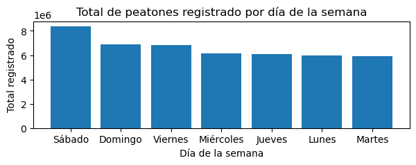

```python
plt.figure(figsize=(7, 2))
plt.bar(peatones_dia.index, peatones_dia.values)
plt.title("Total de peatones registrado por día de la semana")
plt.xlabel("Día de la semana")
plt.ylabel("Total registrado")
plt.show()
```

> **Intrepretación:** El día con mayor número de peatones observados es el sábado seguido por el domingo y viernes.

Si queremos el eje x **ordenado** con respecto a los días de la semana, es decir, que el eje X contenga la semana de lunes a domingo, entonces hay que "reindexar" `reindex` el groupby `peatones_dia`.

```python
dias_orden = ["Lunes", "Martes", "Miércoles", "Jueves", "Viernes", "Sábado", "Domingo"]
peatones_dias_ord = peatones_dia.reindex(dias_orden)
```

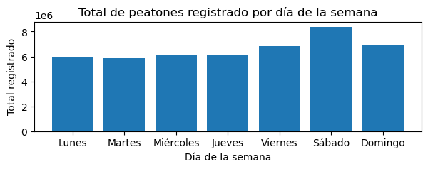

```python
plt.figure(figsize=(7, 2))

plt.bar(peatones_dias_ord.index, peatones_dias_ord.values)

plt.title("Total de peatones registrado por día de la semana")
plt.xlabel("Día de la semana")
plt.ylabel("Total registrado")
plt.show()
```

### 1.5.2 Gráfico plot: total de peatones por día de la semana

De forma análoga al gráfico `bar`podemos trabajar con `plot`.

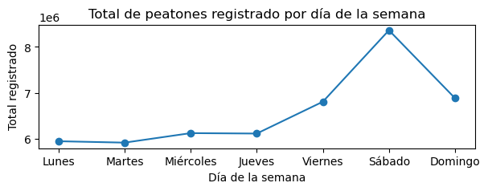

```python
plt.figure(figsize=(7, 2))
plt.plot(peatones_dias_ord.index, peatones_dias_ord.values, marker='o')
plt.title("Total de peatones registrado por día de la semana")
plt.xlabel("Día de la semana")
plt.ylabel("Total registrado")
plt.show()
```

### 1.5.3 Gráfico scatter: total de peatones por día de la semana

Aunque es habitual utilizar `plt.scatter()` para estudiar la relación entre dos variables numéricas, Matplotlib también permite utilizar fechas en el eje X de `plt.scatter()`.

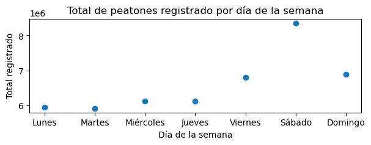

```python
plt.figure(figsize=(7, 2))
plt.scatter(peatones_dias_ord.index, peatones_dias_ord.values)
plt.title("Total de peatones registrado por día de la semana")
plt.xlabel("Día de la semana")
plt.ylabel("Total registrado")
plt.show()
```

## 1.6 Crear un DataFrame con el distrito Centro

```python
df_Centro = df_1[df_1["DISTRITO"] == "Centro"].copy()
```

### 1.6.1 Gráficos plot y scatter: DataFrame del distrito Centro

Gráfico de líneas que tiene en el eje $x$ una variable temporal, categórica o numérica y en el eje $y$ una variable numérica.

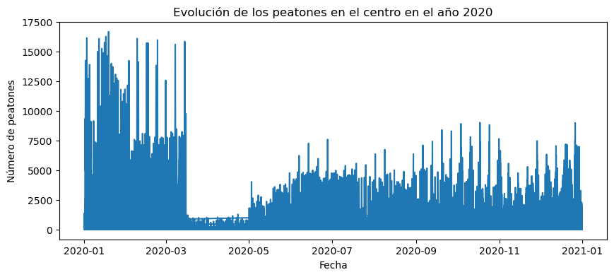

```python
plt.figure(figsize=(10, 4))

plt.plot(df_Centro["FECHA"], df_Centro["PEATONES"])

plt.title("Evolución de los peatones en el centro en el año 2020")
plt.xlabel("Fecha")
plt.ylabel("Número de peatones")
plt.show()
```

Veamos qué día se decrementa notablemente el número de peatones, para ello voy a acortar el eje x y, opcionalmente, el eje y.

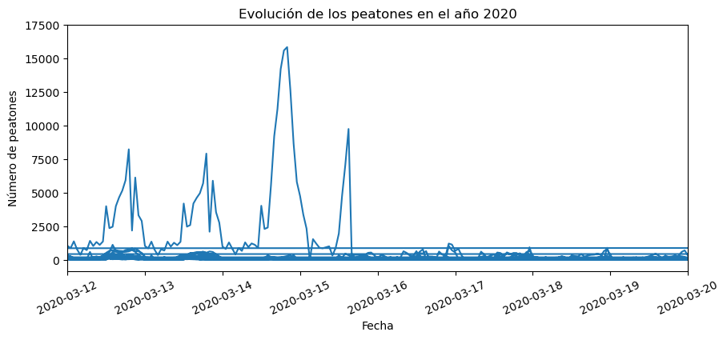

```python
plt.figure(figsize=(10, 4))

plt.plot(df_Centro["FECHA"], df_Centro["PEATONES"])

plt.title("Evolución de los peatones en el año 2020")
plt.xlabel("Fecha")
plt.ylabel("Número de peatones")

plt.xticks(rotation=25)

plt.xlim(pd.Timestamp("2020-03-12"), pd.Timestamp("2020-03-20"))
#plt.ylim(0, 10100)
plt.show()
```

> **Interpretación:** El día 16 de marzo es el primer día que apenas hay peatones por la calle.

**¿Pero que són esas líneas horizontales que veo? No lo entiendo**

`plt.plot(df_Centro["FECHA"], df_Centro["PEATONES"])` representa cada fila del dataFrame como un punto y une cada punto con el siguiente mediante una línea. Si hay muchas observaciones con la misma fecha, se dibujan segmentos verticales que se superponen.

**Mejora:** Aunque lo habitual es utilizar `plt.scatter()` para estudiar la relación entre dos variables numéricas, Matplotlib también permite utilizar fechas en el eje X de `plt.scatter()`.

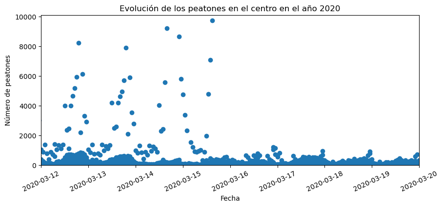

```python
plt.figure(figsize=(10, 4))

plt.scatter(df_Centro["FECHA"], df_Centro["PEATONES"])

plt.title("Evolución de los peatones en el centro en el año 2020")
plt.xlabel("Fecha")
plt.ylabel("Número de peatones")

plt.xticks(rotation=25)

plt.xlim(pd.Timestamp("2020-03-12"), pd.Timestamp("2020-03-20"))
plt.ylim(0, 10100)
plt.show()
```

Seguimos estudiando los peatones que había en el año 2020 en el centro de Madrid. Otra opción es representar el **total** de peatones por fecha sin tener en cuenta la hora. Para ello necesito agrupar por el valor de FECHA ignorando la hora

```
2020-03-15 00:00:00
2020-03-15 01:00:00
2020-03-15 02:00:00
2020-03-15 03:00:00
```

Fíjate que uso `.dt.normalize()` para convertir todas las horas a `00:00:00`.

```python
peatones_fecha = df_Centro.groupby(df_Centro["FECHA"].dt.normalize())["PEATONES"].sum()    #  OJO: uso .dt.normalize()
```

```python
peatones_fecha
```

```
FECHA
2020-01-01    202428
2020-01-02    245700
2020-01-03    297920
2020-01-04    314158
2020-01-05    238255
               ...
2020-12-27    133068
2020-12-28    143242
2020-12-29    138655
2020-12-30    101945
2020-12-31     57220
Name: PEATONES, Length: 366, dtype: int64
```

```python
peatones_fecha.sort_values(ascending=False)
```

```
FECHA
2020-01-04    314158
2020-02-15    305201
2020-02-22    299056
2020-01-03    297920
2020-01-11    293600
               ...
2020-04-05      7559
2020-04-04      6601
2020-04-02      5246
2020-04-03      5016
2020-04-01      4491
Name: PEATONES, Length: 366, dtype: int64
```

Ahora podemos hacer gráficas plot, bar y scatter fijándonos que el eje $y$ pasa de 300.000, pues el mayor valor es 314158.

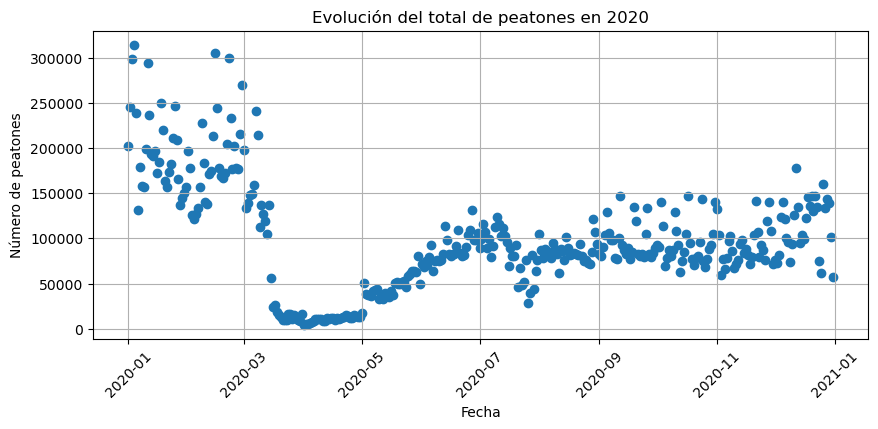

```python
plt.figure(figsize=(10, 4))

#plt.plot(peatones_fecha.index, peatones_fecha.values, marker="o")
#plt.bar(peatones_fecha.index, peatones_fecha.values)
plt.scatter(peatones_fecha.index, peatones_fecha.values)

plt.title("Evolución del total de peatones en 2020")
plt.xlabel("Fecha")
plt.ylabel("Número de peatones")

#plt.xlim(pd.Timestamp("2020-03-12"), pd.Timestamp("2020-03-20"))

plt.xticks(rotation=45)
plt.grid("true")
```

> **Interpretación:** Dentro de marzo, abril y mayo hay un rango de días con el total de número de peatones por fechas es inferior a 50.000. Pero puedo afinar un poco más redudiendo la visión del eje x.

**Pregunta: ¿hasta qué día el número de peatones es inferior a 50.000?**

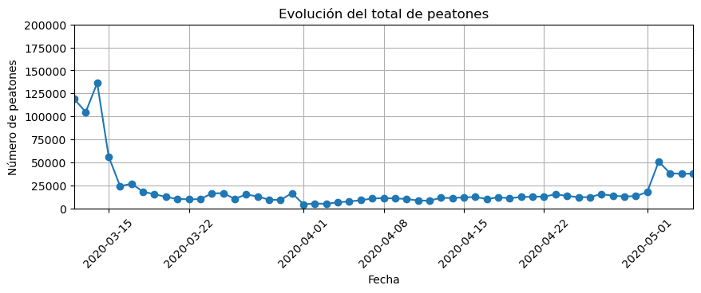

```python
plt.figure(figsize=(10, 3))

plt.plot(peatones_fecha.index, peatones_fecha.values, marker="o")

plt.title("Evolución del total de peatones")
plt.xlabel("Fecha")
plt.ylabel("Número de peatones")

plt.xlim(pd.Timestamp("2020-03-12"), pd.Timestamp("2020-05-05"))
plt.ylim(0,200000)

plt.xticks(rotation=45)
plt.grid("true")
```

> **Interpretación:** A la pregunta de *¿hasta qué día el número de peatones es inferior a 50.000?, la respuesta es el día 2 de mayo.

### 1.6.2 Gráfico bar: DataFrame del distrito Centro

También podemos representar la evolución de los peatones con un diagrama de barras.

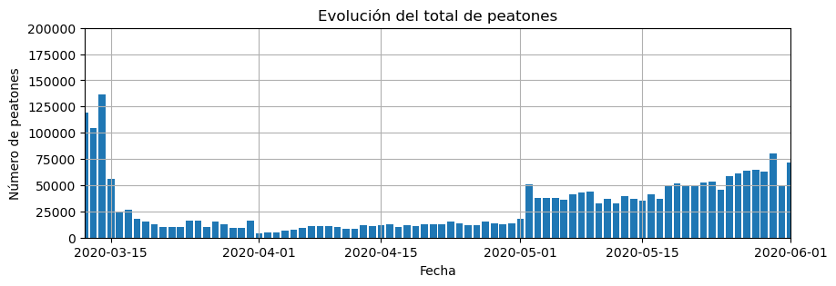

```python
plt.figure(figsize=(10, 3))

plt.bar(peatones_fecha.index, peatones_fecha.values)

plt.title("Evolución del total de peatones")
plt.xlabel("Fecha")
plt.ylabel("Número de peatones")

plt.xlim(pd.Timestamp("2020-03-12"), pd.Timestamp("2020-06-01"))
plt.ylim(0,200000)
plt.grid("true")
```

### 1.6.3 Gráfico hist: DataFrame del distrito Centro

Distribución de los peatones. Es decir, la frecuencia que un observación aparece en la columna `PEATONES` es una observación del fichero. El *histograma* permite ver si la mayoría de las lecturas se concentran en valores pequeños o grandes, etc.

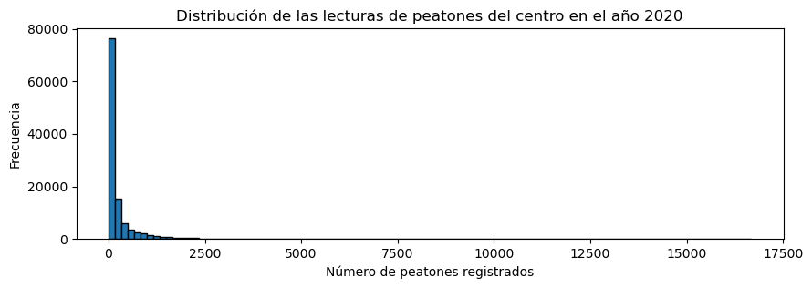

```python
plt.figure(figsize=(10, 3))
plt.hist(df_Centro["PEATONES"], bins=100, edgecolor="black")
plt.title("Distribución de las lecturas de peatones del centro en el año 2020")
plt.xlabel("Número de peatones registrados")
plt.ylabel("Frecuencia")
plt.show()
```

```python
max(df_Centro["PEATONES"])
```

```
16673
```

```python
min(df_Centro["PEATONES"])
```

```
0
```

**Pregunta:** ¿Qué valores de peatones se repiten más?

```python
df_Centro["PEATONES"].value_counts().head(10)
```

```
PEATONES
0    5453
1    2002
2    1707
3    1552
4    1495
5    1392
6    1364
7    1139
8    1107
9    1012
Name: count, dtype: int64
```

```python
df_Centro.shape
```

```
(114192, 7)
```

**Acuérdate** que un histigrama agrupa valores numéricos en intervalos y muestra cuántas observaciones pertenecen a cada intervalo edfinido por `bins`. En nuestro caso, hemos hecho un `bins = 100', calculamos sus límites.

```
array([    0.  ,   166.73,   333.46,   500.19,   666.92,   833.65,
        1000.38,  1167.11,  1333.84,  1500.57,  1667.3 ,  1834.03,
        2000.76,  2167.49,  2334.22,  2500.95,  2667.68,  2834.41,
        3001.14,  3167.87,  3334.6 ,  3501.33,  3668.06,  3834.79,
        4001.52,  4168.25,  4334.98,  4501.71,  4668.44,  4835.17,
        5001.9 ,  5168.63,  5335.36,  5502.09,  5668.82,  5835.55,
        6002.28,  6169.01,  6335.74,  6502.47,  6669.2 ,  6835.93,
        7002.66,  7169.39,  7336.12,  7502.85,  7669.58,  7836.31,
        8003.04,  8169.77,  8336.5 ,  8503.23,  8669.96,  8836.69,
        9003.42,  9170.15,  9336.88,  9503.61,  9670.34,  9837.07,
       10003.8 , 10170.53, 10337.26, 10503.99, 10670.72, 10837.45,
       11004.18, 11170.91, 11337.64, 11504.37, 11671.1 , 11837.83,
       12004.56, 12171.29, 12338.02, 12504.75, 12671.48, 12838.21,
       13004.94, 13171.67, 13338.4 , 13505.13, 13671.86, 13838.59,
       14005.32, 14172.05, 14338.78, 14505.51, 14672.24, 14838.97,
       15005.7 , 15172.43, 15339.16, 15505.89, 15672.62, 15839.35,
       16006.08, 16172.81, 16339.54, 16506.27, 16673.  ])
```

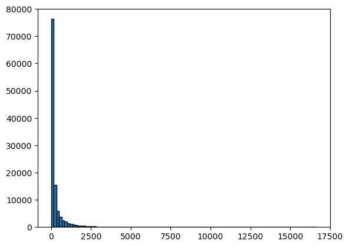

```python
_ , limites, _ = plt.hist(df_Centro["PEATONES"], bins=100, edgecolor="black")
limites
```

Entonces esos casi 80.000 observaciones son las que caen entre los valores 0 y 166.73.

Si hacemos un número de cajas (114.190) aproximado al número de observaciones (114.192), entonces vemos que la caja más alta pasa de la marca de 5000 del eje $y$. De cho, el valor que más aparece es el 0 con 5453 observaciones.

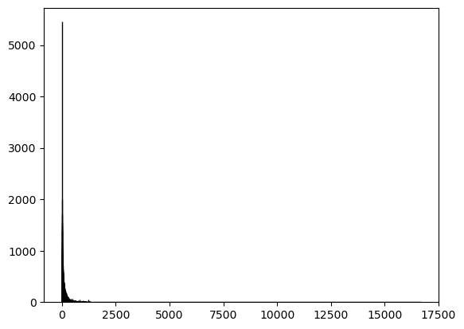

```python
plt.hist(df_Centro["PEATONES"], bins=114190, edgecolor="black")
```

### 1.6.4 Gráfico boxplot: DataFrame del distrito Centro

Diagrama de caja y bigotes.

El diagrama de caja resume la distribución con la mediana, los cuartiles y los posibles valores atípicos. Los valores atípicos no tienen por qué ser errores: pueden corresponder a momentos o ubicaciones con mucho tránsito.

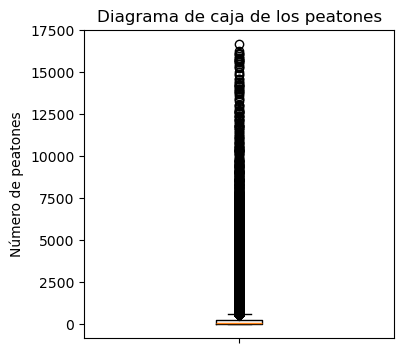

```python
plt.figure(figsize=(4, 4))
plt.boxplot(df_Centro["PEATONES"])
plt.title("Diagrama de caja de los peatones")
plt.ylabel("Número de peatones")
plt.xticks([1], [""])  # muestra la etiqueta "" en la posición 1 del eje X
plt.show()
```

Como hay muchos valores atipicos no se aprecia.

La solución más sencilla es utilizar `showfliers=False`, que oculta los valores atípicos en el gráfico, pero no los elimina de los datos ni del cálculo de los cuartiles. De paso voy a darle un poco de color.

- `showfliers=False`: oculta los valores atípicos.
- `patch_artist=True`: Permite colorear la caja.
- `boxprops`: Configura el color de la caja.
- `medianprops`: Destaca la mediana en rojo.
- `plt.grid(axis="y", alpha=0.5)` Añade una cuadrícula horizontal con transparencia 0,5.

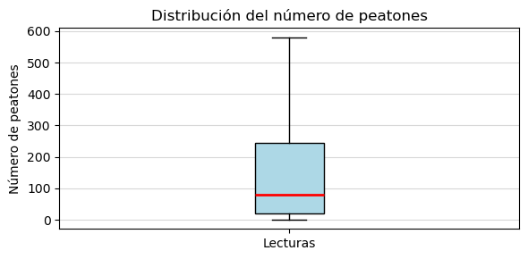

```python
plt.figure(figsize=(6, 3))

plt.boxplot(
    df_Centro["PEATONES"].dropna(),
    showfliers = False,
    patch_artist = True,
    medianprops=dict(color="red", linewidth=2),
    boxprops = dict(facecolor="lightblue"),
)

plt.title("Distribución del número de peatones")
plt.ylabel("Número de peatones")
plt.xticks([1], ["Lecturas"])
plt.grid(axis="y", alpha=0.5)

plt.tight_layout()
plt.show()
```

```python
df_Centro["PEATONES"].describe()
```

```
count    114192.000000
mean        313.038199
std         802.175405
min           0.000000
25%          21.000000
50%          81.000000
75%         245.000000
max       16673.000000
Name: PEATONES, dtype: float64
```

**Interpretación**

La mediana es 81 peatones. Esto significa que aproximadamente la mitad de las observaciones tiene 81 peatones o menos.

El 50% central de las observaciones está entre 21 y 245 peatones. Por tanto, hay diferencias importantes entre las lecturas.

Asimetría: La parte superior de la caja y el bigote superior son más largos. Esto indica que existen observaciones con valores elevados respecto a los valores habituales.

## 1.7 Peatones de Madrid a las 23:00

```python
df_Madrid_23h = df_1[df_1["HORA"] == pd.to_datetime("23:00", format="%H:%M").time()].copy()
```

### 1.7.1 Gráfico plot, bar, scatter: Peatones en Madrid a las 23:00

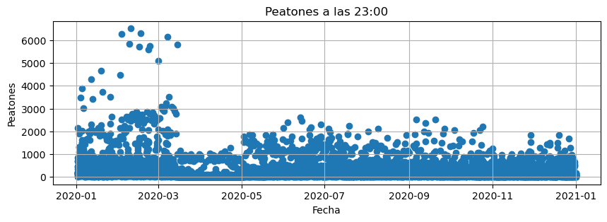

```python
plt.figure(figsize=(10, 3))
#plt.plot(df_Madrid_23h["FECHA"], df_Madrid_23h["PEATONES"])
#plt.bar(df_Madrid_23h["FECHA"], df_Madrid_23h["PEATONES"])
plt.scatter(df_Madrid_23h["FECHA"], df_Madrid_23h["PEATONES"])
plt.title("Peatones a las 23:00")
plt.xlabel("Fecha")
plt.ylabel("Peatones")
plt.grid(True)
```

> **Interpretación:** En enero, febrero y comienzo de marzo se observa una gran dispersión en el número de peatones, con valores que habitualmente se sitúan por debajo de 3.000, aunque aparecen algunas observaciones superiores a 6.000. Final de marzo y abril se produce una disminución muy notable del número de peatones, con gran mayoría por debajo de 1.000 peatones. A partir de mayo se aprecia una recuperación parcial de la actividad, aunque los valores siguen siendo inferiores a los observados al comienzo del año. Aparecen algunos registros puntuales superiores a 2.000 peatones.

### 1.7.2 Gráfico hist: Peatones en Madrid a las 23:00

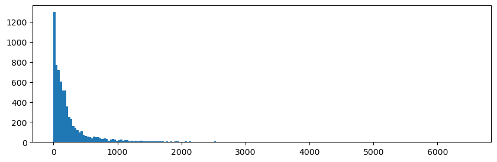

```python
plt.figure(figsize=(10, 3))
plt.hist(df_Madrid_23h["PEATONES"], bins = 200)
plt.show()
```

**Interpretación:** Este histograma representa la distribución del número de peatones registrados a las 11 de la noche donde, la mayor parte de las observación corresponde a un número reducido de peatones, pues la barra de mayor frecuencia se encuentra en los valores próximos a cero. Por otra parte, a medida que aumenta el número de peatones, disminuye la frecuencia de las observaciones. Esto significa que hay muchas observaciones con pocos peatones y unas pocas observación con cantidades muy elevadas. De hecho, hay algúna observación que se aproxima a 6.500.

### 1.7.3 Gráfico barh: Peatones en Madrid a las 23:00 por distrito

Queremos saber a qué distritos pertenecen las observaciones cuya hora es 23:00. Por esto, vamos a agrupar los `PEATONES`por `DISTRITO`.

```python
peatones_distrito_23h = (
    df_Madrid_23h.groupby("DISTRITO")["PEATONES"]
    .sum()
    .sort_values()
)
peatones_distrito_23h
```

```
DISTRITO
Latina               37667
Chamberí             91443
Arganzuela          154105
Moncloa-Aravaca     171921
Centro             1456600
Name: PEATONES, dtype: int64
```

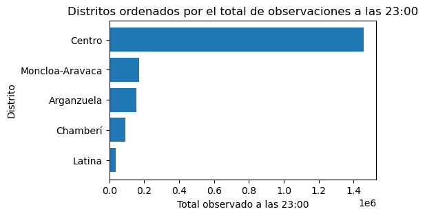

```python
plt.figure(figsize=(5, 3))
plt.barh(peatones_distrito_23h.index, peatones_distrito_23h.values)
plt.title("Distritos ordenados por el total de observaciones a las 23:00")
plt.xlabel("Total observado a las 23:00")
plt.ylabel("Distrito")
```

### 1.7.4 Gráfico pie: Peatones en Madrid a las 23:00 por distrito

Vemos a hacer un *pie chart* que represente qué porcentaje del total de peatones registrados que corresponde a cada distrito. Por lo tanto, necesitamos el groupby `peatones_distrito_23h` de la suma los PEATONES de cada DISTRITO.

```python
peatones_distrito_23h.values
```

```
array([  37667,   91443,  154105,  171921, 1456600])
```

```python
peatones_distrito_23h.index
```

```
Index(['Latina', 'Chamberí', 'Arganzuela', 'Moncloa-Aravaca', 'Centro'], dtype='object', name='DISTRITO')
```

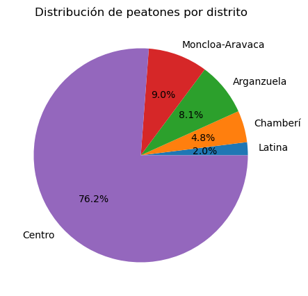

```python
plt.figure(figsize=(5, 5))

plt.pie(peatones_distrito_23h.values, labels=peatones_distrito_23h.index, autopct="%1.1f%%")

plt.title("Distribución de peatones por distrito")
plt.show()
```

> **Interpretación** La distribución de los peatones entre los distritos es muy desigual. El distrito Centro concentra el 76,2 % de los registros, mientras que Moncloa-Aravaca y Arganzuela representan conjuntamente el 17,1 %. Chamberí y Latina tienen una participación mucho menor.

## 1.8 Peatones en el Centro a las 23:00

Seleccionar las observaciones de `df_Centro` de las 23:00.

Observación: Necesitarás combinar las condiciones de distrito y hora si partes de `df_1`, pero aquí ya tenemos filtrado el distrito. Por esto, es importante partir de `df_Centro` y añadir la condición de que la hora sea `23:00`.

Después, observamos las filas y columnas de la tabla.

```python
import datetime
# df_Centro_23h = df_Centro[df_Centro["HORA"] == pd.to_datetime("23:00", format="%H:%M").time()].copy()
df_Centro_23h = df_Centro[df_Centro["HORA"] == datetime.time(23, 0)].copy()
df_Centro_23h.shape
```

```
(4758, 7)
```

Además de la metodología que hemos visto para estudiar los peatones del distrito Centro (sección 1.6) y a las 23:00 (sección 1.7), podemos añadir otras variables como `DIRECCIÓN`.

### 1.8.1 Gráfico barh: Peatones en el Centro a las 23:00, calles más transitadas

Queremos saber las calles de Centro con más peatones a las 23:00.

Primero debemos agrupar del dataframe `df_Centro_23h` por `DIRECCIÓN` y calcular la suma de los valores de `PEATONES`.

```python
peatones_calle_centro_23h = (df_Centro_23h.groupby("DIRECCIÓN")["PEATONES"].sum().sort_values())
peatones_calle_centro_23h.sort_values()
```

```
DIRECCIÓN
Calle Huertas                7465
Calle Bailén                27213
Calle San Bernardo          29704
Paseo de Recoletos          37194
Calle Mayor                 37889
Calle Atocha                43208
Calle Hortaleza             47600
Calle Alcalá                48047
Carrera de San Jerónimo     63524
Calle Toledo               205490
Gran Vía                   223105
Calle Fuencarral           686161
Name: PEATONES, dtype: int64
```

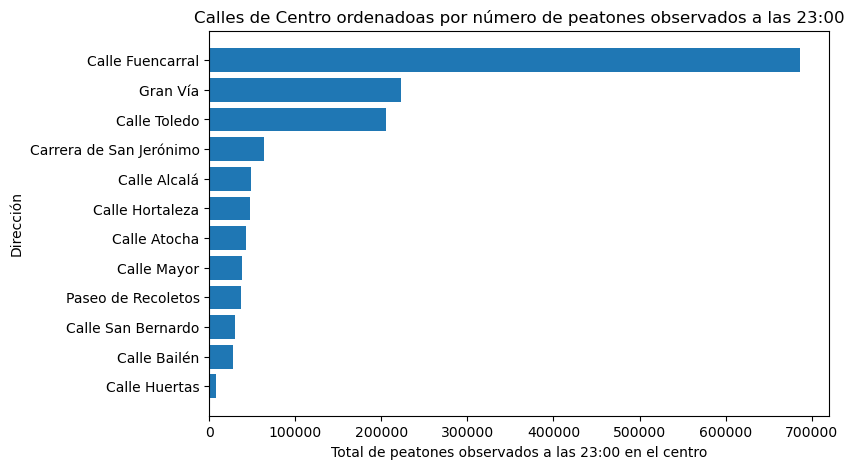

```python
plt.figure(figsize=(8, 5))

plt.barh(peatones_calle_centro_23h.index, peatones_calle_centro_23h.values)

plt.title("Calles de Centro ordenadoas por número de peatones observados a las 23:00")
plt.xlabel("Total de peatones observados a las 23:00 en el centro")
plt.ylabel("Dirección")
plt.show()
```

## 1.9 Total de peatones de Madrid por mes

Para estudiar los totales por mes, primero creamos una nueva columna `MES` extrayendo el número de mes de `FECHA` mediante `.dt`, ya que la columna `FECHA` contiene valores de fecha y hora.

```python
df_1["MES"] = df_1["FECHA"].dt.month
```

Ahora agrupamos y sumamos los peatones, es decir, agrupamos por `MES` y seleccionamos la columna `PEATONES`.

¿Qué función de agregación necesitamos para obtener el total de peatones de cada mes?

Comprueba el resultado de la agrupación. Deberías obtener un valor para cada uno de los meses disponibles.

```python
peatones_mes = df_1.groupby("MES")["PEATONES"].sum()

peatones_mes.sort_values(ascending=False)
```

```
MES
1     8006983
2     7361212
12    4316985
10    3646475
9     3587082
6     3503517
11    3461438
7     3380743
3     3241413
8     3179427
5     1968095
4      490313
Name: PEATONES, dtype: int64
```

### 1.9.1 Gráfico plot, bar, scatter: Total de peatones de Madrid por mes

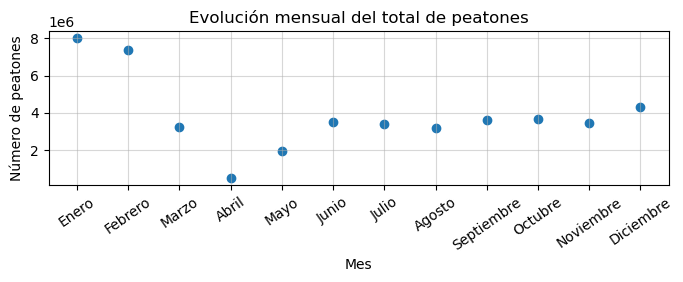

```python
meses_ord = [ "Enero", "Febrero", "Marzo", "Abril", "Mayo", "Junio", "Julio", "Agosto",
    "Septiembre", "Octubre", "Noviembre", "Diciembre"]

plt.figure(figsize=(8, 2))
#plt.plot(peatones_mes.index, peatones_mes.values, marker="o")
#plt.bar(peatones_mes.index, peatones_mes.values)
plt.scatter(peatones_mes.index, peatones_mes.values)
plt.title("Evolución mensual del total de peatones")
plt.xlabel("Mes")
plt.ylabel("Número de peatones")
plt.xticks(range(1, 13),meses_ord,rotation=35)
plt.grid(True, alpha=0.5)  # transparencia
```

> **Interpretación:** el mes con menos peatones fue abril, seguido por mayo. En lo que queda de año no se alcazarón cifras anteriores a la pandemia.

### 1.9.2 Gráfico plot y scatter (n): Total de peatones de Madrid por mes, desglosado en distritos

Además de visualizar el total de peatones de Madrid por mes, quiero desglosarlo por distritos.

```python
df_1["DISTRITO"].unique()
```

```
array(['Centro', 'Chamberí', 'Latina', 'Moncloa-Aravaca', 'Arganzuela'],
      dtype=object)
```

Voy a crear tantos dataframes como distritos.

```python
import numpy as np

centro = df_1[df_1["DISTRITO"] == "Centro"].groupby("MES")["PEATONES"].sum()
chamberi = df_1[df_1["DISTRITO"] == "Chamberí"].groupby("MES")["PEATONES"].sum()
Latina = df_1[df_1["DISTRITO"] == "Latina"].groupby("MES")["PEATONES"].sum()
MoncloaAravaca = df_1[df_1["DISTRITO"] == "Moncloa-Aravaca"].groupby("MES")["PEATONES"].sum()
Arganzuela = df_1[df_1["DISTRITO"] == "Arganzuela"].groupby("MES")["PEATONES"].sum()
```

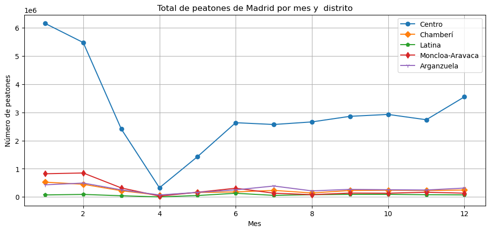

```python
plt.figure(figsize=(12, 5))

plt.plot(centro.index, centro.values, marker="o", label="Centro")
plt.plot(chamberi.index, chamberi.values, marker="D", label="Chamberí")
plt.plot(Latina.index, Latina.values, marker="p", label="Latina")
plt.plot(MoncloaAravaca.index, MoncloaAravaca.values, marker="d", label="Moncloa-Aravaca")
plt.plot(Arganzuela.index, Arganzuela.values, marker="1", label="Arganzuela")

plt.title("Total de peatones de Madrid por mes y  distrito")
plt.xlabel("Mes")
plt.ylabel("Número de peatones")
plt.legend()
plt.grid(True)
plt.show()
```

Como la mayoría de las observaciones pertenen al distrito centro, no nos deja "ver" al resto. Quitamos el distrito centro.

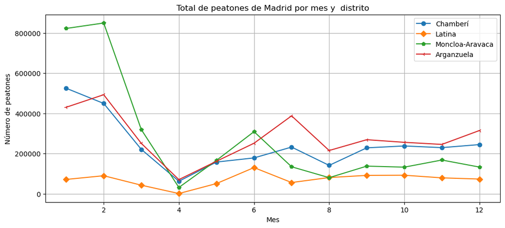

```python
plt.figure(figsize=(12, 5))

plt.plot(chamberi.index, chamberi.values, marker="o", label="Chamberí")
plt.plot(Latina.index, Latina.values, marker="D", label="Latina")
plt.plot(MoncloaAravaca.index, MoncloaAravaca.values, marker="p", label="Moncloa-Aravaca")
plt.plot(Arganzuela.index, Arganzuela.values, marker="3", label="Arganzuela")

plt.title("Total de peatones de Madrid por mes y  distrito")
plt.xlabel("Mes")
plt.ylabel("Número de peatones")
plt.legend()
plt.grid(True)
plt.show()
```

> **Interpretación:** La distribución mensual de los peatones presenta importantes diferencias entre distritos. Se observa una caída generalizada durante los primeros meses de la primavera, seguida de una recuperación desigual. Moncloa-Aravaca registra los mayores valores al comienzo del año, sin embargo al final del año es el 3/4. Camberí y Arganzuela tienen un comportamiento similar. La Latina presenta los menores totales durante prácticamente todo el periodo, teniendo sus valores más altos en junio .

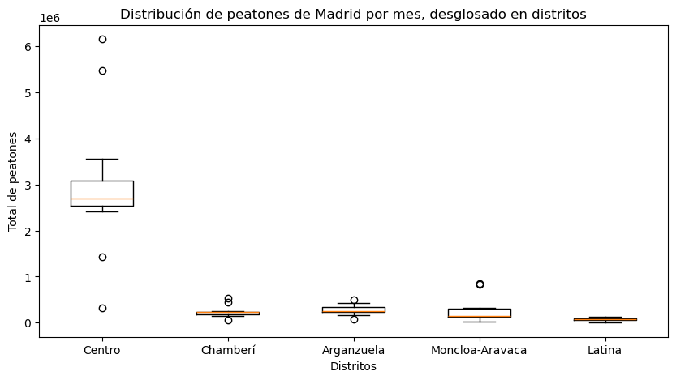

```python
valores = [centro.values, chamberi.values, Arganzuela.values,
         MoncloaAravaca.values, Latina.values]

distritos = ["Centro", "Chamberí", "Arganzuela",
             "Moncloa-Aravaca", "Latina"]

plt.figure(figsize=(10, 5))

plt.boxplot(valores, labels=distritos)

plt.title("Distribución de peatones de Madrid por mes, desglosado en distritos")
plt.xlabel("Distritos")
plt.ylabel("Total de peatones")

plt.show()
```

Quitamos el distrito Centro

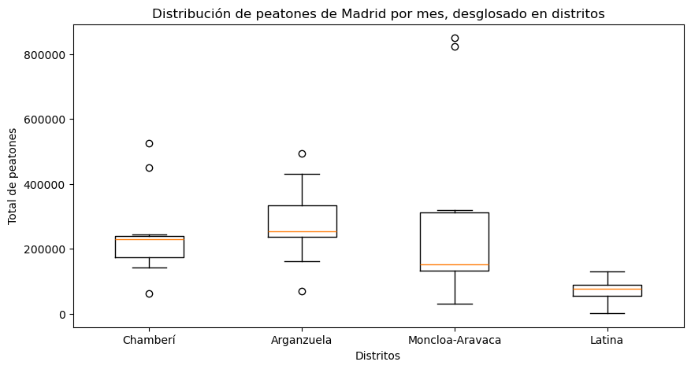

```python
valores = [chamberi.values, Arganzuela.values,
         MoncloaAravaca.values, Latina.values]

distritos = ["Chamberí", "Arganzuela",
             "Moncloa-Aravaca", "Latina"]

plt.figure(figsize=(10, 5))

plt.boxplot(valores, tick_labels=distritos)

plt.title("Distribución de peatones de Madrid por mes, desglosado en distritos")
plt.xlabel("Distritos")
plt.ylabel("Total de peatones")

plt.show()
```

> **Interpretación:** Moncloa-Aravaca presenta una caja bastante amplia, lo que indica que existe una gran variabilidad en el 50 % central de sus valores mensuales.

Arganzuela también presenta una dispersión importante.

En cambio, Latina tiene una caja más reducida, por lo que sus valores mensuales centrales están más concentrados.

Con respecto a los valores atípicos, se concentran en:

- Chamberí con dos valores atípicos elevados y uno inferior.
- Arganzuela con un valor atípico elevado y otro inferior.
- Moncloa-Aravaca con dos valores atípicos extremadamente elevados.

Estos valores podrían corresponder a meses con una actividad peatonal excepcionalmente alta o baja. No necesariamente son errores en los datos.

```
  A partir de aquí es repetitivo
```

## 1.10 Calcular el total de peatones en una fecha concreta y por distrito

Queremos saber cuántos peatones había en la calle, por ejemplo, el 15 de marzo del 2020. Para esto hay que seguir los siguientes pasos:

1. A partir del DataFrame df_1, seleccionar los registros del 15 de marzo de 2020 y dejarlos en un nuevo DataFrame `df_fecha`.
2. Calcular el total de peatones aplicando el método `sum()` a la variable `PEATONES`.
3. Calcular el total por distrito

```python
# 1. Seleccionar los registros del 15 de marzo de 2020

fecha = pd.to_datetime("15/03/2020", dayfirst=True)

df_fecha = df_1[df_1["FECHA"].dt.date == fecha.date()].copy()

# 2. Calcular el total de peatones

total_peatones = df_fecha["PEATONES"].sum()

print("Total de peatones:", total_peatones, "\n")

# 3. Calcular el total por distrito

peatones_distrito = df_fecha.groupby("DISTRITO")["PEATONES"].sum()

peatones_distrito = peatones_distrito.sort_values(ascending=False)

print(peatones_distrito)
```

```
Total de peatones: 76945

DISTRITO
Centro             56432
Chamberí            7329
Arganzuela          6234
Moncloa-Aravaca     3555
Latina              3395
Name: PEATONES, dtype: int64
```

### 1.10.1 Gráfico barh: Número de peatones por distrito el 15 de marzo

Las barras horizontales comparan los totales de los distritos en la fecha elegida.

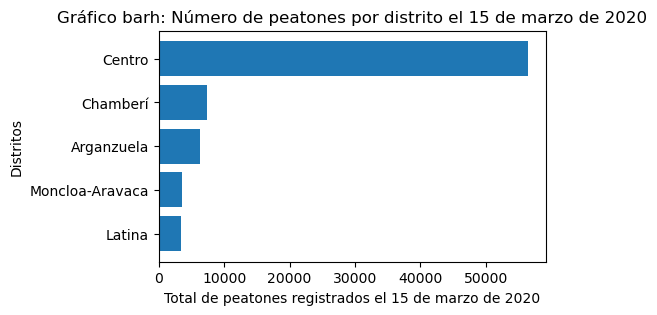

```python
peatones_distrito_fecha_grafico = peatones_distrito.sort_values()

plt.figure(figsize=(5, 3))
plt.barh(peatones_distrito_fecha_grafico.index, peatones_distrito_fecha_grafico.values)
plt.title("Gráfico barh: Número de peatones por distrito el 15 de marzo de 2020")
plt.xlabel("Total de peatones registrados el 15 de marzo de 2020")
plt.ylabel("Distritos")

plt.show()
```

### 1.10.2 Gráfico pie: Número de peatones por distrito el 15 de marzo

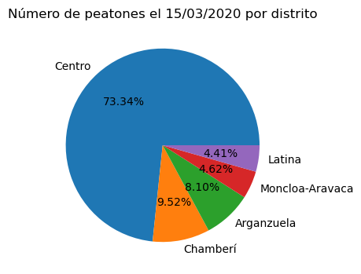

```python
plt.figure(figsize=(4, 4))
plt.pie(peatones_distrito.values, labels=peatones_distrito.index, autopct="%1.2f%%")
plt.title("Número de peatones el 15/03/2020 por distrito")
```

## 1.11 Las 10 calles con más peatones

Pasos:

1. A partir del DataFrame df_1, agrupa los registros por calle, utilizando la columna DIRECCIÓN.
2. Calcula el total de peatones registrados en cada calle.
3. Ordena las calles de mayor a menor número de peatones.
4. Muestra las 10 calles con mayor número total de peatones.

```python
# 1. Calcular el total de peatones por calle

peatones_calle = df_1.groupby("DIRECCIÓN")["PEATONES"].sum()

# 2. Ordenar de mayor a menor

peatones_calle = peatones_calle.sort_values(ascending=False)

# 3. Seleccionar las 10 calles con más peatones

top_10 = peatones_calle.head(10)

print(top_10)


# Se puede hacer directamente en una instrucción
# pero hacemos 3 pasos para observar el proceso
# df_1.groupby("DIRECCION")["PEATONES"].sum().sort_values(ascending=False).head(10)
```

```
DIRECCIÓN
Calle Fuencarral                20192010
Gran Vía                         5617293
Calle Princesa                   3283849
Calle Toledo                     2821574
Plaza del Emperador Carlos V     2185960
Calle Génova                     1759394
Carrera de San Jerónimo          1215547
Ronda de Valencia                1160608
Alberto Aguilera                 1149314
Calle Atocha                     1046587
Name: PEATONES, dtype: int64
```

### 1.11.1 Gráfico: las 10 calles con más peatones

Las barras horizontales ordenan las calles por el total acumulado de lecturas de `PEATONES` en el periodo. El formato horizontal resulta adecuado porque los nombres de las calles pueden ser largos.

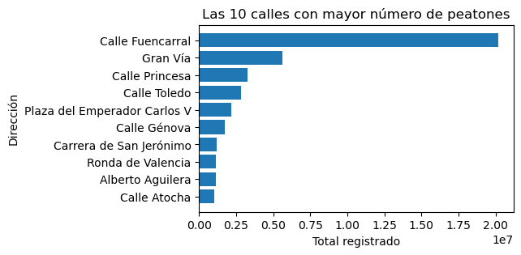

```python
top_10_grafico = top_10.sort_values()

plt.figure(figsize=(5, 3))
plt.barh(top_10_grafico.index, top_10_grafico.values)
plt.title("Las 10 calles con mayor número de peatones")
plt.xlabel("Total registrado")
plt.ylabel("Dirección")

plt.show()
```

**Interpretación:** La *Calle Fuencarral* (20192010) es la más concurrida, según la disposición de los sensores, con una diferencia importante respecto a la segunda calle más concurrida, *Gran Vía* (5617293). El resto de calles decrecen más lentamente.

## 1.12 ¿A qué hora hay más peatones?

Pasos:

1. Agrupa los registros por hora.
2. Calcula el total de peatones registrados en cada hora.
3. Ordena los resultados de mayor a menor.
4. Identifica la hora con mayor y menor número total de peatones.

```python
df_1.columns
```

```
Index(['FECHA', 'HORA', 'PEATONES', 'DISTRITO', 'DIRECCIÓN', 'NÚMERO',
       'DIA_SEMANA', 'MES'],
      dtype='object')
```

```python
df_1.groupby("HORA")["PEATONES"].sum().sort_values(ascending=False)
```

```
HORA
20:00:00    4469552
21:00:00    4169983
19:00:00    4013067
18:00:00    3304044
14:00:00    3059466
22:00:00    2906280
13:00:00    2815571
15:00:00    2751493
17:00:00    2732509
16:00:00    2488252
12:00:00    2398073
23:00:00    1911736
11:00:00    1650985
00:00:00    1253469
10:00:00    1217730
09:00:00     931989
01:00:00     846635
08:00:00     678473
02:00:00     592709
07:00:00     475331
03:00:00     426225
04:00:00     384638
05:00:00     335120
06:00:00     330353
Name: PEATONES, dtype: int64
```

### 1.12.1 Gráfico: total de peatones registrado por hora del día

Para visualizar la evolución a lo largo de las 24 horas, ordenamos las horas cronológicamente (de 00:00 a 23:00), no por el tamaño de los totales. Los valores suman las observaciones de esa hora en todos los días y puntos de aforo disponibles.

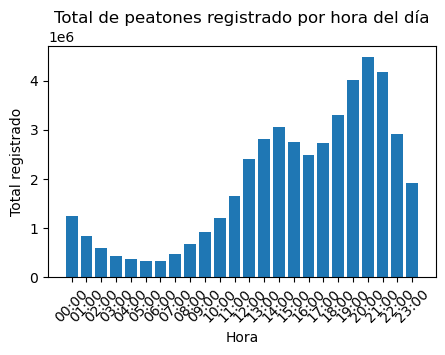

```python
peatones_hora_grafico = df_1.groupby("HORA")["PEATONES"].sum().sort_index()
etiquetas_horas = [hora.strftime("%H:%M") for hora in peatones_hora_grafico.index]

plt.figure(figsize=(5, 3))
plt.bar(etiquetas_horas, peatones_hora_grafico.values)
plt.title("Total de peatones registrado por hora del día")
plt.xlabel("Hora")
plt.ylabel("Total registrado")
plt.xticks(rotation=45)

plt.show()
```